# SYMFLUENCE Tutorial 04a — Logan River Workshop (Distributed, Cloud Data)

## Introduction

This workshop notebook demonstrates basin-scale hydrological modeling using SYMFLUENCE's semi-distributed representation approach for the Logan River at Logan, Utah using cloud-based data sources. The workflow includes:

1. **Configuration** — Set up a semi-distributed basin model for the Logan River
2. **Domain Definition** — Delineate the watershed using TauDEM
3. **Data Acquisition** — Fetch RDRS forcing data and USGS streamflow observations from cloud sources
4. **Model Execution** — Run a hydrological model: SUMMA
5. **Evaluation & Calibration** — Assess model performance and calibrate parameters

The **Logan River at Logan** is a snow-dominated mountain watershed in the Bear River Range of the Wasatch Mountains. USGS station 10109000 provides streamflow observations. The watershed covers approximately 550 km² with elevations ranging from ~1,400 m to over 2,900 m.

### Switching Models

To use a different model, change the `model=` parameter in the configuration cell below. Supported models include: `'NGEN'`, `'HBV'`, `'SACSMA'`, `'SUMMA'`, `'HYPE'`, `'FUSE'`.

**Launch this notebook from the CLI:**

```
symfluence example launch 4a
```

```python
# Environment verification
import sys
import os
import warnings
from pathlib import Path
import pandas as pd
import geopandas as gpd
import numpy as np
import matplotlib.pyplot as plt

# Suppress experimental module warnings for cleaner output
warnings.filterwarnings('ignore', message='.*is an EXPERIMENTAL module.*')
warnings.filterwarnings('ignore', message='.*import failed.*')

print(f"Python executable: {sys.executable}")

# Verify SYMFLUENCE is available
try:
    import symfluence
    print(f"SYMFLUENCE version: {symfluence.__version__}")
    print(f"SYMFLUENCE location: {Path(symfluence.__file__).parent}")
except ImportError:
    print("ERROR: SYMFLUENCE not found. Please activate the symfluence environment.")
    sys.exit(1)
```

```
Python executable: /srv/conda/envs/symfluence/bin/python
SYMFLUENCE version: 0.8.4
SYMFLUENCE location: /srv/conda/envs/symfluence/lib/python3.11/site-packages/symfluence
```

```python
# Fix working directory if running from .ipynb_checkpoints
current_dir = Path.cwd()
print(f"Current directory: {current_dir}")

# If we're in .ipynb_checkpoints, move up to parent directory
if '.ipynb_checkpoints' in str(current_dir):
    correct_dir = current_dir.parent
    os.chdir(correct_dir)
    print(f"Changed to: {Path.cwd()}")
else:
    print("Working directory is correct")

# Verify we're in the workshop notebooks directory
expected_notebook = Path.cwd() / '04a_logan_river_workshop_distributed.ipynb'
if not expected_notebook.exists():
    print(f"WARNING: Expected notebook not found at {expected_notebook}")
else:
    print("Notebook location verified")
```

```
Current directory: /home/jovyan/SYMFLUENCE/examples/04_workshop_notebooks
Working directory is correct
Notebook location verified
```

## Step 1 — Configuration

Create a configuration for the Logan River semi-distributed basin model. Key settings:

- **Domain**: Semi-distributed GRU representation
- **Forcing**: RDRS (Regional Deterministic Reanalysis System) — hourly gridded data
- **Observations**: USGS streamflow from station 10109000
- **Period**: 4 years (2018-2021) with 1-year spinup

```python
# Step 1 — Create basin-scale configuration
import symfluence as symfluence_pkg
from symfluence import SYMFLUENCE
from symfluence.core.config.models import SymfluenceConfig

# ── Workshop toggle ──────────────────────────────────────────────────────────
# Set to True on JupyterHub / 2i2c to redirect all heavy I/O to /tmp/.
# On a local machine or HPC with fast home storage, leave as False.
use_tmp_dir = True
# ─────────────────────────────────────────────────────────────────────────────

def resolve_symfluence_paths():
    """Resolve SYMFLUENCE code/data paths for repo based and JupyterHub Docker image based symfluence installs."""
    pkg_dir = Path(symfluence_pkg.__file__).resolve().parent
    repo_root = None

    for candidate in [pkg_dir, *pkg_dir.parents]:
        if (
            (candidate / "src" / "symfluence").exists()
            or (candidate / ".git").exists()
            or (candidate / "pyproject.toml").exists()
        ):
            repo_root = candidate.resolve()
            break

    if repo_root is not None:
        code_dir = repo_root
        data_dir = repo_root.parent / "SYMFLUENCE_data"
        mode = "symfluence repository detected"
    else:
        code_dir = Path(os.environ.get("SYMFLUENCE_CODE_DIR", str(Path.home() / "SYMFLUENCE")))
        data_dir = Path(os.environ.get("SYMFLUENCE_DATA_DIR", str(Path.home() / "SYMFLUENCE_data")))
        mode = "installed package / JupyterHub fallback"

    return code_dir, data_dir, mode

code_dir, data_dir, path_mode = resolve_symfluence_paths()
original_data_dir = data_dir

if use_tmp_dir:
    data_dir = Path('/tmp/SYMFLUENCE_data')
    data_dir.mkdir(parents=True, exist_ok=True)
    # Symlink installs (TauDEM, model binaries) from the original location
    installs_link = data_dir / 'installs'
    if not installs_link.exists():
        installs_source = original_data_dir / 'installs'
        if installs_source.exists():
            installs_link.symlink_to(installs_source.resolve())
            print(f"  Symlinked installs: {installs_link} -> {installs_source.resolve()}")
        else:
            print(f"  WARNING: installs not found at {installs_source}")
    print(f"use_tmp_dir=True  -->  data directory redirected to {data_dir}")

if not data_dir.exists():
    raise RuntimeError(
        f"SYMFLUENCE data directory does not exist: {data_dir}\n"
        "Set SYMFLUENCE_DATA_DIR or create the directory before continuing."
    )

installs_dir = data_dir / 'installs'
if not installs_dir.exists():
    print(
        f"WARNING: installs directory not found at {installs_dir}.\n"
        "If using the JupyterHub/Docker image, ensure your installs symlink is configured."
    )

print(f"Notebook directory: {current_dir}")
print(f"SYMFLUENCE path resolution mode: {path_mode}")
print(f"SYMFLUENCE data directory: {data_dir}")
print(f"SYMFLUENCE code directory: {code_dir}")
print(f"SYMFLUENCE installs directory: {installs_dir}")

# Build config kwargs
config_kwargs = dict(
    # Basic identification
    domain_name='Logan_River_at_Logan_distributed',
    experiment_id='workshop_run_summa_distributed',

    # Paths
    SYMFLUENCE_DATA_DIR=str(data_dir),
    SYMFLUENCE_CODE_DIR=str(code_dir),
    TAUDEM_DIR='default',

    # Model
    model='SUMMA',
    routing_model='mizuRoute',
    SETTINGS_SUMMA_USE_PARALLEL_SUMMA=True,
    SETTINGS_SUMMA_CPUS_PER_TASK=4,

    params_to_calibrate=(
        'k_soil,'  # hydraulic conductivity of soil (m s-1)
        'theta_sat,'  # porosity (-)
        'aquiferBaseflowExp,'  # baseflow exponent (-)
        'aquiferBaseflowRate,'  # baseflow rate when aquifer storage = aquiferScaleFactor (m s-1)
        'qSurfScale,'  # scaling factor in the surface runoff parameterization (-)
        'summerLAI,'  # maximum leaf area index at the peak of the growing season (m2 m-2)
        'frozenPrecipMultip,'  # frozen precipitation multiplier (-)
        'Fcapil,'  # capillary retention as a fraction of the total pore volume (-)
        'tempCritRain,'  # critical temperature where precipitation is rain (K)
        'heightCanopyTop,'  # height of top of the vegetation canopy above ground surface (m)
        'heightCanopyBottom,'  # height of bottom of the vegetation canopy above ground surface (m)
        'windReductionParam,'  # canopy wind reduction parameter (-)
        'vGn_n'  # van Genuchten "n" parameter (-)
    ),
    basin_params_to_calibrate=(
        'routingGammaScale,'  # scale parameter in Gamma distribution used for sub-grid routing (s)
        'routingGammaShape'  # shape parameter in Gamma distribution used for sub-grid routing (-)
    ),

    # Simulation period (4 years: 2018-2021)
    time_start='2018-01-01 01:00',
    time_end='2021-12-31 23:00',
    spinup_period='2018-01-01, 2018-12-31',
    calibration_period='2019-01-01, 2019-12-31',
    evaluation_period='2020-01-01, 2020-12-31',

    # Spatial domain (Logan River at Logan, UT — USGS 10109000)
    pour_point_coords='41.743098/-111.786432',
    bounding_box_coords='42.15/-111.90/41.70/-111.40',
    definition_method='semi-distributed',
    discretization='GRUs',
    stream_threshold=5000.0,

    # Data sources
    data_access='cloud',
    forcing_dataset='RDRS',
    forcing_measurement_height=2,
    dem_source='copdem90',
    download_dem=True,

    # Streamflow observations
    station_id='10109000',
    streamflow_data_provider='USGS',
    download_usgs_data=True,

    # Calibration
    OPTIMIZATION_METHODS=['iteration'],
    optimization_target='streamflow',
    iterative_optimization_algorithm='DDS',
    SKIP_WARM_START=True,  # Defaults to False (seeds with previous run)
    INITIAL_GUESS=None,  # Defaults to None; can seed with a dict of parameter values
    PARAMETER_BOUNDS={  # Set explicit parameter bounds
        "k_soil": {"min": 1.0e-6, "max": 1.0e-4,
                "transform": "log"},  # Default: [1.0e-8, 1.0e-2]
        "theta_sat": {"min": 0.4, "max": 0.7},  # Default: [0.35, 0.65]
        "aquiferBaseflowExp": {"min": 1.0, "max": 5.0},  # Default: [1.0, 5.0]
        "aquiferBaseflowRate": {"min": 1.0e-9, "max": 1.0e-6,
                                "transform": "log"},  # Default: [1.0e-9, 1.0e-5]
        "qSurfScale": {"min": 1.0, "max": 100.0,
                    "transform": "log"},  # Default: [1.0, 100.0]
        "summerLAI": {"min": 2.0, "max": 6.0},  # Default: [0.01, 10.0]
        "frozenPrecipMultip": {"min": 0.25, "max": 1.25},  # Default: [0.5, 5.0]
        "Fcapil": {"min": 0.05, "max": 0.15},  # Default: [0.005, 0.2]
        "tempCritRain": {"min": 272.15, "max": 275.15},  # Default: [272.16, 274.16]
        "heightCanopyTop": {"min": 5.0, "max": 25.0},  # Default: [0.05, 100.0]
        "heightCanopyBottom": {"min": 1.0, "max": 5.0},  # Default: [0.0, 5.0]
        "windReductionParam": {"min": 0.25, "max": 0.75},  # Default: [0.25, 1.0]
        "vGn_n": {"min": 1.1, "max": 1.6},  # Default: [1.2, 4.0]
        "routingGammaScale": {"min": 100.0, "max": 100000.0,
                            "transform": "log"},  # Default: [1.0, 100000.0]
        "routingGammaShape": {"min": 2.0, "max": 4.0},  # Default: [2.0, 5.0]
    },
    DDS_R=0.2,  # Step size in normalized parameter space; default is 0.2
    optimization_metric='KGE',
    calibration_timestep='hourly',
    iterations=50,
)
config = SymfluenceConfig.from_minimal(**config_kwargs)

# Save configuration
config_path = Path('./config_logan_river_summa_distributed.yaml')
config_dict = config.to_dict(flatten=True)
import yaml
with open(config_path, 'w') as f:
    yaml.dump(config_dict, f, default_flow_style=False, sort_keys=False)
print(f"  Config saved to: {config_path}")

# Initialize SYMFLUENCE
symfluence = SYMFLUENCE(config)
project_dir = symfluence.managers['project'].setup_project()
pour_point_path = symfluence.managers['project'].create_pour_point()

print(f"\nProject structure created at: {project_dir}")
print(f"Pour point shapefile: {pour_point_path}")
print("=" * 80)
```

```
use_tmp_dir=True  -->  data directory redirected to /tmp/SYMFLUENCE_data
Notebook directory: /home/jovyan/SYMFLUENCE/examples/04_workshop_notebooks
SYMFLUENCE path resolution mode: installed package / JupyterHub fallback
SYMFLUENCE data directory: /tmp/SYMFLUENCE_data
SYMFLUENCE code directory: /opt/symfluence
SYMFLUENCE installs directory: /tmp/SYMFLUENCE_data/installs
  Config saved to: config_logan_river_summa_distributed.yaml
============================================================
2026-05-27 07:28:17 ● SYMFLUENCE Logging Initialized
2026-05-27 07:28:17 ● Domain: Logan_River_at_Logan_distributed
2026-05-27 07:28:17 ● Experiment ID: workshop_run_summa_distributed
2026-05-27 07:28:17 ● Log Level: INFO
2026-05-27 07:28:17 ● Log File: /tmp/SYMFLUENCE_data/domain_Logan_River_at_Logan_distributed/_workLog_Logan_River_at_Logan_distributed/symfluence_general_Logan_River_at_Logan_distributed_20260527_072817.log
============================================================
2026-05-27 07:28:17 ● Configuration logged to: /tmp/SYMFLUENCE_data/domain_Logan_River_at_Logan_distributed/_workLog_Logan_River_at_Logan_distributed/config_Logan_River_at_Logan_distributed_20260527_072817.yaml
2026-05-27 07:28:17 ● SYMFLUENCE initialized
2026-05-27 07:28:18 ● Setting up project for domain: Logan_River_at_Logan_distributed
2026-05-27 07:28:18 ● Project directory created at: /tmp/SYMFLUENCE_data/domain_Logan_River_at_Logan_distributed
2026-05-27 07:28:18 ● Pour point shapefile created successfully: /tmp/SYMFLUENCE_data/domain_Logan_River_at_Logan_distributed/shapefiles/pour_point/Logan_River_at_Logan_distributed_pourPoint.shp

Project structure created at: /tmp/SYMFLUENCE_data/domain_Logan_River_at_Logan_distributed
Pour point shapefile: /tmp/SYMFLUENCE_data/domain_Logan_River_at_Logan_distributed/shapefiles/pour_point/Logan_River_at_Logan_distributed_pourPoint.shp
================================================================================
```

## Step 2 — Domain Definition

Delineate the Logan River watershed using TauDEM and create semi-distributed GRUs.

### Step 2a — Geospatial Attribute Acquisition

Acquire elevation, land cover, and soil data from cloud sources.

```python
# Step 2a — Acquire geospatial attributes from cloud
symfluence.managers['data'].acquire_attributes()
print("Attribute acquisition complete")
```

```
2026-05-27 07:28:18 ● Starting attribute acquisition
2026-05-27 07:28:18 ● Cloud data access enabled for attributes (DEM_SOURCE: copdem90)
2026-05-27 07:28:18 ● Acquiring attributes: 3 tasks with 3 workers
2026-05-27 07:28:18 ● Submitting: DEM
2026-05-27 07:28:18 ● Submitting: soil
2026-05-27 07:28:18 ● Downloading Copernicus DEM GLO-90 for bbox: {'lat_min': 41.7, 'lat_max': 42.15, 'lon_min': -111.9, 'lon_max': -111.4}
2026-05-27 07:28:18 ● Submitting: landcover
2026-05-27 07:28:18 ● Acquiring soil class data from HydroShare (primary source)
2026-05-27 07:28:18 ● Fetching tile: Copernicus_DSM_COG_30_N41_00_W112_00_DEM
2026-05-27 07:28:18 ● Fetching MODIS Land Cover (MCD12Q1 v061) from Zenodo
2026-05-27 07:28:18 ● Downloading soil data from HydroShare...
2026-05-27 07:28:18 ● MODIS landcover bbox: {'lat_min': 41.7, 'lat_max': 42.15, 'lon_min': -111.9, 'lon_max': -111.4}
2026-05-27 07:28:19 ● Downloaded Copernicus_DSM_COG_30_N41_00_W112_00_DEM
2026-05-27 07:28:19 ● Fetching tile: Copernicus_DSM_COG_30_N42_00_W112_00_DEM
2026-05-27 07:28:20 ● Downloaded Copernicus_DSM_COG_30_N42_00_W112_00_DEM
2026-05-27 07:28:20 ● Merging 2 tiles into /tmp/SYMFLUENCE_data/domain_Logan_River_at_Logan_distributed/data/attributes/elevation/dem/domain_Logan_River_at_Logan_distributed_elv.tif
2026-05-27 07:28:20 ● Completed: DEM
07:28:23 ● ✓ Downloaded 414.5 MB from HydroShare
2026-05-27 07:28:23 ● Extracting soil data from archive...
07:28:26 ● ✓ Soil data acquired from HydroShare: /tmp/SYMFLUENCE_data/domain_Logan_River_at_Logan_distributed/data/attributes/soilclass/domain_Logan_River_at_Logan_distributed_soil_classes.tif
2026-05-27 07:28:26 ● Completed: soil
2026-05-27 07:28:55 ● Completed: landcover
Attribute acquisition complete
```

### Step 2b — Watershed Delineation

Delineate the watershed boundary from the pour point using TauDEM.

```python
# Step 2b — Watershed delineation
watershed_path = symfluence.managers['domain'].define_domain()
print(f"Watershed delineation complete")
```

```
2026-05-27 07:28:55 ● Starting geofabric delineation for Logan_River_at_Logan_distributed using method: stream_threshold
2026-05-27 07:28:55 ● Created interim directory: /tmp/SYMFLUENCE_data/domain_Logan_River_at_Logan_distributed/taudem-interim-files/d8
2026-05-27 07:28:56 ● Completed TauDEM common step
2026-05-27 07:28:56 ● Completed TauDEM common step
2026-05-27 07:28:57 ● Completed TauDEM common step
2026-05-27 07:28:57 ● Running stream_threshold stream identification
2026-05-27 07:28:57 ● Completed threshold method step
2026-05-27 07:28:58 ● Completed threshold method step
2026-05-27 07:28:58 ● Completed threshold method step
2026-05-27 07:28:59 ● Completed threshold method step
2026-05-27 07:28:59 ● Threshold-based stream identification completed with threshold=5000.0
2026-05-27 07:28:59 ● Completed all TauDEM steps
2026-05-27 07:28:59 ● Completed GDAL polygonization using direct method
2026-05-27 07:28:59 ● CRS is not defined for /tmp/SYMFLUENCE_data/domain_Logan_River_at_Logan_distributed/taudem-interim-files/d8/basin-watersheds.shp. Setting to EPSG:4326.
2026-05-27 07:28:59 ● Found 6 rows with duplicate GRU_ID values
2026-05-27 07:28:59 ● Removed duplicates, keeping largest area for each GRU_ID
2026-05-27 07:28:59 ● Remaining GRUs: 25
2026-05-27 07:28:59 ● Ensuring CRS consistency. Target CRS: EPSG:4326
```

```
2026-05-27 07:28:59 ● Subset basins shapefile saved to: /tmp/SYMFLUENCE_data/domain_Logan_River_at_Logan_distributed/shapefiles/river_basins/Logan_River_at_Logan_distributed_riverBasins_semidistributed.shp
2026-05-27 07:28:59 ● Subset rivers shapefile saved to: /tmp/SYMFLUENCE_data/domain_Logan_River_at_Logan_distributed/shapefiles/river_network/Logan_River_at_Logan_distributed_riverNetwork_semidistributed.shp
2026-05-27 07:28:59 ● Geofabric delineation completed for Logan_River_at_Logan_distributed
2026-05-27 07:28:59 ● Completed task: Domain Definition in 3.32 seconds
2026-05-27 07:28:59 ● Domain definition completed using method: semidistributed
Watershed delineation complete
```

### Step 2c — Domain Discretization

Create semi-distributed GRUs for the watershed.

```python
# Step 2c — Discretization (semi-distributed GRUs)
hru_path = symfluence.managers['domain'].discretize_domain()
print("Domain discretization complete")
```

```
2026-05-27 07:28:59 ● Created directory: /tmp/SYMFLUENCE_data/domain_Logan_River_at_Logan_distributed/shapefiles/catchment/semidistributed/workshop_run_summa_distributed
2026-05-27 07:28:59 ● Completed task: Domain Discretization in 0.15 seconds
Domain discretization complete
```

### Step 2d — Visualization

Visualize the delineated watershed and pour point.

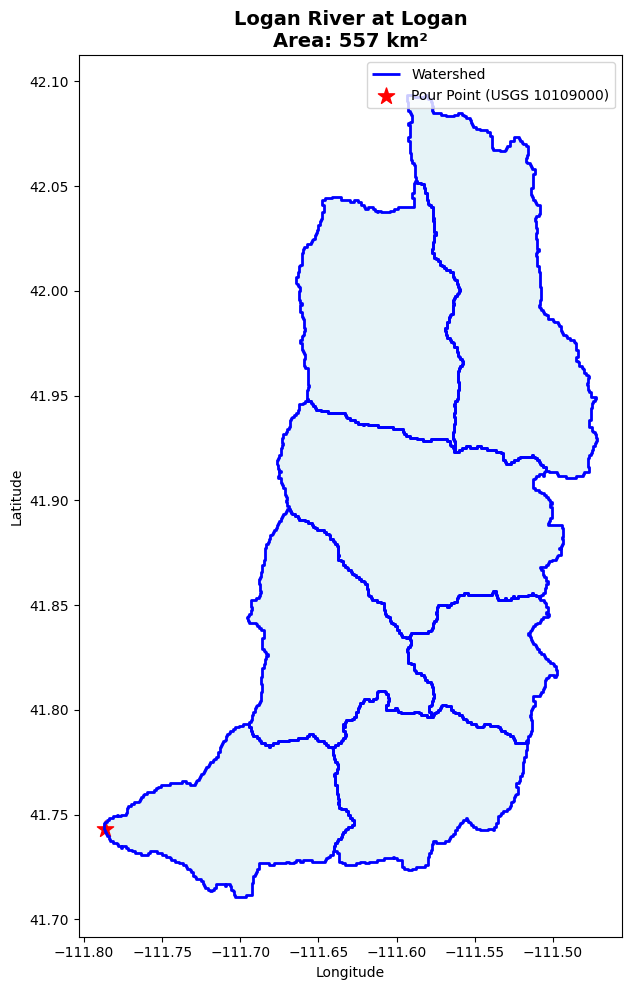

```
Watershed area: 557 km²
Number of HRUs: 7 (semi-distributed)
```

```python
# Step 2d — Basin visualization
# Load spatial data
basin_path = project_dir / 'shapefiles' / 'river_basins' / f"{config.domain.name}_riverBasins_semidistributed.shp"
hru_file = project_dir / 'shapefiles' / 'catchment' / 'semidistributed' / config.domain.experiment_id / f"{config.domain.name}_HRUs_GRUs.shp"

watershed_gdf = gpd.read_file(str(basin_path))
hru_gdf = gpd.read_file(str(hru_file))
pour_point_gdf = gpd.read_file(pour_point_path)

# Calculate area (UTM Zone 12N for Utah)
watershed_proj = watershed_gdf.to_crs('EPSG:32612')
area_km2 = watershed_proj.geometry.area.sum() / 1e6

# Plot
fig, ax = plt.subplots(1, 1, figsize=(10, 10))
watershed_gdf.boundary.plot(ax=ax, color='blue', linewidth=2, label='Watershed')
hru_gdf.plot(ax=ax, facecolor='lightblue', edgecolor='blue', alpha=0.3)
pour_point_gdf.plot(ax=ax, color='red', markersize=150, marker='*', label=f'Pour Point (USGS {config.evaluation.streamflow.station_id})')

ax.set_title(f"Logan River at Logan\nArea: {area_km2:.0f} km²", fontweight='bold', fontsize=14)
ax.legend(loc='upper right')
ax.set_xlabel('Longitude')
ax.set_ylabel('Latitude')
plt.tight_layout()
plt.show()

print(f"Watershed area: {area_km2:.0f} km²")
print(f"Number of HRUs: {len(hru_gdf)} (semi-distributed)")
```

## Step 3 — Data Acquisition and Preprocessing

Fetch forcing data (RDRS) and streamflow observations (USGS) from cloud sources.

### Step 3a — USGS Streamflow Observations

Download and process USGS streamflow data for station 10109000.

```python
# Step 3a — Download and process USGS streamflow data
symfluence.managers['data'].process_observed_data()
print("USGS streamflow data acquisition complete")
```

```
2026-05-27 07:28:59 ● Processing observed data
2026-05-27 07:28:59 ● Acquiring additional observations: ['USGS_STREAMFLOW']
2026-05-27 07:28:59 ● Acquiring observations: 1 tasks (serial)
2026-05-27 07:28:59 ● Starting: USGS_STREAMFLOW
2026-05-27 07:28:59 ● Downloading USGS streamflow data for station 10109000
2026-05-27 07:29:06 ● Successfully downloaded USGS data to /tmp/SYMFLUENCE_data/domain_Logan_River_at_Logan_distributed/data/observations/streamflow/raw_data/usgs_10109000_raw.rdb
2026-05-27 07:29:06 ● Completed: USGS_STREAMFLOW
2026-05-27 07:29:06 ● Processing FLUXNET data
2026-05-27 07:29:06 ● FLUXNET data processing is disabled in configuration
2026-05-27 07:29:06 ● Processing registry-based observation: usgs_streamflow
2026-05-27 07:29:06 ● Downloading USGS streamflow data for station 10109000
2026-05-27 07:29:12 ● Successfully downloaded USGS data to /tmp/SYMFLUENCE_data/domain_Logan_River_at_Logan_distributed/data/observations/streamflow/raw_data/usgs_10109000_raw.rdb
2026-05-27 07:29:12 ● Processing USGS streamflow data from /tmp/SYMFLUENCE_data/domain_Logan_River_at_Logan_distributed/data/observations/streamflow/raw_data/usgs_10109000_raw.rdb
2026-05-27 07:29:13 ● USGS streamflow processing complete: /tmp/SYMFLUENCE_data/domain_Logan_River_at_Logan_distributed/data/observations/streamflow/preprocessed/Logan_River_at_Logan_distributed_streamflow_processed.csv
2026-05-27 07:29:13 ● Observed data processing completed successfully
USGS streamflow data acquisition complete
```

### Step 3b — RDRS Meteorological Forcing

Download RDRS forcing data from cloud. RDRS (Regional Deterministic Reanalysis System) provides:

- Hourly temporal resolution
- Complete forcing variables: precipitation, temperature, humidity, wind, radiation, pressure

```python
# Step 3b — Acquire RDRS forcing data from cloud
symfluence.managers['data'].acquire_forcings()
print("RDRS forcing acquisition complete")
```

```
2026-05-27 07:29:13 ● Starting forcing data acquisition
2026-05-27 07:29:13 ● Cloud data access enabled for RDRS
07:29:13 ● ✓ RDRS supports cloud data access
2026-05-27 07:29:14 ● Cache hit: RDRS_cfe05c16efaf21ed (age=0 days)
07:29:14 ● ✓ Using cached forcing data: RDRS_cfe05c16efaf21ed
07:29:14 ● ✓ Copied cached file to: /tmp/SYMFLUENCE_data/domain_Logan_River_at_Logan_distributed/data/forcing/raw_data/RDRS_cfe05c16efaf21ed.nc
RDRS forcing acquisition complete
```

### Step 3c — Model-Agnostic Preprocessing

Standardize forcing data: variable names, units, and spatial averaging over the watershed.

```python
# Step 3c — Model-agnostic preprocessing
symfluence.managers['data'].run_model_agnostic_preprocessing()
print("Model-agnostic preprocessing complete")
```

```
2026-05-27 07:29:14 ● Starting geospatial statistics calculation
2026-05-27 07:29:14 ● Calculating soil statistics
2026-05-27 07:29:14 ● Soil raster CRS: GEOGCS["WGS 84",DATUM["World Geodetic System 1984",SPHEROID["WGS 84",6378137,298.257223563]],PRIMEM["Greenwich",0],UNIT["degree",0.0174532925199433,AUTHORITY["EPSG","9122"]],AXIS["Latitude",NORTH],AXIS["Longitude",EAST]]
2026-05-27 07:29:14 ● Catchment shapefile CRS: EPSG:4326
2026-05-27 07:29:14 ● CRS match - no reprojection needed
2026-05-27 07:29:14 ● Soil statistics saved to /tmp/SYMFLUENCE_data/domain_Logan_River_at_Logan_distributed/shapefiles/catchment_intersection/with_soilgrids/catchment_with_soilclass.shp
2026-05-27 07:29:14 ● Calculating land statistics
2026-05-27 07:29:14 ● Land raster CRS: GEOGCS["WGS 84",DATUM["World Geodetic System 1984",SPHEROID["WGS 84",6378137,298.257223563]],PRIMEM["Greenwich",0],UNIT["degree",0.0174532925199433,AUTHORITY["EPSG","9122"]],AXIS["Latitude",NORTH],AXIS["Longitude",EAST]]
2026-05-27 07:29:14 ● Catchment shapefile CRS: EPSG:4326
2026-05-27 07:29:14 ● CRS match - no reprojection needed
2026-05-27 07:29:14 ● Land statistics saved to /tmp/SYMFLUENCE_data/domain_Logan_River_at_Logan_distributed/shapefiles/catchment_intersection/with_landclass/catchment_with_landclass.shp
2026-05-27 07:29:14 ● Calculating elevation statistics (memory-optimized chunked mode)
2026-05-27 07:29:14 ● Loaded 7 catchments
2026-05-27 07:29:14 ● DEM raster CRS: GEOGCS["WGS 84",DATUM["World Geodetic System 1984",SPHEROID["WGS 84",6378137,298.257223563]],PRIMEM["Greenwich",0],UNIT["degree",0.0174532925199433,AUTHORITY["EPSG","9122"]],AXIS["Latitude",NORTH],AXIS["Longitude",EAST]]
2026-05-27 07:29:14 ● Catchment shapefile CRS: EPSG:4326
2026-05-27 07:29:14 ● CRS match - no reprojection needed
2026-05-27 07:29:14 ● Processing all catchments in single batch
2026-05-27 07:29:14 ● Computed elevation for 7/7 catchments (100.0%)
2026-05-27 07:29:14 ● Elevation statistics saved to /tmp/SYMFLUENCE_data/domain_Logan_River_at_Logan_distributed/shapefiles/catchment_intersection/with_dem/catchment_with_dem.shp
2026-05-27 07:29:14 ● Starting to merge RDRS forcing data
2026-05-27 07:29:14 ● Processing consolidated cloud file: RDRS_cfe05c16efaf21ed.nc
```

[output not shown]

```
2026-05-27 07:29:25 ● Successfully calculated elevation for 34/81 geometries
2026-05-27 07:29:25 ● RDRS shapefile created and saved to /tmp/SYMFLUENCE_data/domain_Logan_River_at_Logan_distributed/shapefiles/forcing/forcing_RDRS.shp
```

```
2026-05-27 07:29:26 ● Detected 7 forcing variables: ['surface_air_pressure', 'surface_downwelling_longwave_flux', 'surface_downwelling_shortwave_flux', 'precipitation_flux', 'air_temperature', 'specific_humidity', 'wind_speed']
2026-05-27 07:29:26 ● Running easymore to create remapping weights...
2026-05-27 07:29:27 ● Remapping weights created: /tmp/SYMFLUENCE_data/domain_Logan_River_at_Logan_distributed/shapefiles/catchment_intersection/with_forcing/Logan_River_at_Logan_distributed_RDRS_HRU_ID_remapping.csv
2026-05-27 07:29:27 ● Processing 48 files in serial mode
```

```
2026-05-27 07:47:07 ● Serial processing complete: 48/48 successful
2026-05-27 07:47:07 ● Model-agnostic preprocessing completed successfully
Model-agnostic preprocessing complete
```

## Step 4 — Model Configuration and Execution

Run model-specific preprocessing and execute the selected model.

```python
# Step 4a — Model-specific preprocessing
print(f"Preprocessing for {config.model.hydrological_model}...")
symfluence.managers['model'].preprocess_models()
print(f"{config.model.hydrological_model} preprocessing complete")
```

```
Preprocessing for SUMMA...
2026-05-27 07:47:07 ● Automatically adding MIZUROUTE to workflow (dependency of SUMMA)
2026-05-27 07:47:07 ● Starting SUMMA spatial preprocessing
2026-05-27 07:47:07 ● Starting memory-efficient temperature lapse rate and data step application
2026-05-27 07:47:07 ● Converting /tmp/SYMFLUENCE_data/domain_Logan_River_at_Logan_distributed/shapefiles/catchment_intersection/with_forcing/Logan_River_at_Logan_distributed_RDRS_intersected_shapefile.shp to CSV format
2026-05-27 07:47:07 ● Successfully created /tmp/SYMFLUENCE_data/domain_Logan_River_at_Logan_distributed/shapefiles/catchment_intersection/with_forcing/Logan_River_at_Logan_distributed_RDRS_intersected_shapefile.csv
2026-05-27 07:47:07 ● Loading topology data...
2026-05-27 07:47:07 ● Loaded topology data: 33 rows, 0.12 MB
2026-05-27 07:47:07 ● Columns after rename: ['S_1_GRU_ID', 'S_1_GRU_ar', 'S_1_gru_to', 'S_1_HRU_ID', 'S_1_hru_ty', 'S_1_elev_m', 'S_1_center', 'S_1_cent_1', 'S_1_HRU_ar', 'S_1_ID_t', 'S_1_lat_t', 'S_1_lon_t', 'S_1_order', 'AS1', 'IDS1']
2026-05-27 07:47:07 ● Sample HRU IDs: [5, 5, 5, 5, 5]
2026-05-27 07:47:07 ● Found 48 forcing files to process
2026-05-27 07:47:07 ● Pre-calculating lapse rate corrections (Rate: 6.50 K/km)...
2026-05-27 07:47:07 ● Prepared lapse corrections for 7 HRUs
2026-05-27 07:47:07 ● Lapse values HRU IDs: [5, 6, 11, 13, 17, 18, 21]
2026-05-27 07:47:07 ● Processing files in batches of 48
2026-05-27 07:47:12 ● Completed processing of 48 RDRS forcing files with temperature lapsing
2026-05-27 07:47:12 ● Created directory: /tmp/SYMFLUENCE_data/domain_Logan_River_at_Logan_distributed/settings/SUMMA
2026-05-27 07:47:12 ● Copying SUMMA base settings
2026-05-27 07:47:12 ● SUMMA base settings copied to /tmp/SYMFLUENCE_data/domain_Logan_River_at_Logan_distributed/settings/SUMMA
2026-05-27 07:47:12 ● Creating forcing file list
2026-05-27 07:47:12 ● Looking for SUMMA forcing files in /tmp/SYMFLUENCE_data/domain_Logan_River_at_Logan_distributed/data/forcing/SUMMA_input with prefix 'Logan_River_at_Logan_distributed_RDRS' and extension '.nc'
2026-05-27 07:47:12 ● Found 48 unique RDRS forcing files for SUMMA
2026-05-27 07:47:12 ● Forcing file list created at /tmp/SYMFLUENCE_data/domain_Logan_River_at_Logan_distributed/settings/SUMMA/forcingFileList.txt with 48 files
2026-05-27 07:47:12 ● Creating SUMMA file manager
2026-05-27 07:47:13 ● SUMMA file manager created at /tmp/SYMFLUENCE_data/domain_Logan_River_at_Logan_distributed/settings/SUMMA/fileManager.txt
2026-05-27 07:47:13 ● Creating attributes file
2026-05-27 07:47:13 ● Attributes file created at: /tmp/SYMFLUENCE_data/domain_Logan_River_at_Logan_distributed/settings/SUMMA/attributes.nc
2026-05-27 07:47:13 ● Inserting land class into attributes file
2026-05-27 07:47:13 ● 0 HRUs were identified as containing only open water. Note that SUMMA skips hydrologic calculations for such HRUs.
2026-05-27 07:47:13 ● Inserting soil class into attributes file
2026-05-27 07:47:13 ● Inserting elevation into attributes file
2026-05-27 07:47:13 ● Calculating and inserting aspect into attributes file
2026-05-27 07:47:13 ● Calculating aspect from DEM for each HRU
2026-05-27 07:47:13 ● Successfully inserted aspect data into attributes file
2026-05-27 07:47:13 ● Calculating and inserting tangent of slope into attributes file
2026-05-27 07:47:13 ● Calculating tangent of slope from DEM for each HRU
2026-05-27 07:47:13 ● Successfully inserted tangent of slope data into attributes file
2026-05-27 07:47:13 ● Creating initial conditions (cold state) file
2026-05-27 07:47:13 ● Unable to filter forcing HRU IDs against catchment shapefile: 'None of [None] are in the columns'
2026-05-27 07:47:13 ● Initial conditions file created at: /tmp/SYMFLUENCE_data/domain_Logan_River_at_Logan_distributed/settings/SUMMA/coldState.nc
2026-05-27 07:47:13 ● Creating trial parameters file
2026-05-27 07:47:13 ● Unable to filter forcing HRU IDs against catchment shapefile: 'None of [None] are in the columns'
2026-05-27 07:47:13 ● Trial parameters file created at: /tmp/SYMFLUENCE_data/domain_Logan_River_at_Logan_distributed/settings/SUMMA/trialParams.nc
2026-05-27 07:47:13 ● SUMMA preprocessing completed successfully
2026-05-27 07:47:13 ● Creating mizuRoute setup directory: /tmp/SYMFLUENCE_data/domain_Logan_River_at_Logan_distributed/settings/mizuRoute
2026-05-27 07:47:13 ● Copying mizuRoute base settings
2026-05-27 07:47:13 ● mizuRoute base settings copied
2026-05-27 07:47:13 ● Creating network topology file
2026-05-27 07:47:13 ● Loading pour point from /tmp/SYMFLUENCE_data/domain_Logan_River_at_Logan_distributed/shapefiles/pour_point/Logan_River_at_Logan_distributed_pourPoint.shp
2026-05-27 07:47:13 ● Closest segment to pour point: 21 (distance: 31.3 units)
2026-05-27 07:47:13 ● Fixed 1 invalid downstream segment references:
```

```
2026-05-27 07:47:13 ●   Segment 21 had invalid downstream ID 24 -> set to -9999 (outlet)
2026-05-27 07:47:13 ● Network topology file created at /tmp/SYMFLUENCE_data/domain_Logan_River_at_Logan_distributed/settings/mizuRoute/topology.nc
2026-05-27 07:47:13 ● MIZU_FROM_MODEL not set, inferred 'SUMMA' from HYDROLOGICAL_MODEL
2026-05-27 07:47:13 ● Should we remap?: False
2026-05-27 07:47:13 ● mizuRoute spatial preprocessing completed
2026-05-27 07:47:13 ● Model-specific preprocessing completed
SUMMA preprocessing complete
```

```python
# Step 4b — Model execution
print(f"Running {config.model.hydrological_model}...")
print(f"Simulation period: {config.domain.time_start} to {config.domain.time_end}")
symfluence.managers['model'].run_models()
print("Model execution complete")

# Step 4c — Post-processing (extract streamflow to standardized results CSV)
print(f"Post-processing for {config.model.hydrological_model}")
symfluence.managers['model'].postprocess_results()
print("Post-processing complete")
```

```
Running SUMMA...
Simulation period: 2018-01-01 01:00 to 2021-12-31 23:00
2026-05-27 07:47:13 ● Starting model runs
2026-05-27 07:47:13 ● Automatically adding MIZUROUTE to workflow (dependency of SUMMA)
2026-05-27 07:47:13 ● Execution workflow order: ['SUMMA', 'MIZUROUTE']
2026-05-27 07:47:13 ● Running model: SUMMA
2026-05-27 07:47:13 ● SLURM not available, falling back to local SUMMA GRU splitting
2026-05-27 07:47:13 ● Starting local parallel SUMMA run
2026-05-27 07:47:13 ● Parallel SUMMA: 7 GRUs across 4 processes (1-2 GRUs each)
2026-05-27 07:48:04 ● All 4 GRU splits completed in 51.1s
2026-05-27 07:48:04 ● Merged 4 splits -> workshop_run_summa_distributed_timestep.nc (7 HRUs)
2026-05-27 07:48:05 ● Merged 4 splits -> workshop_run_summa_distributed_day.nc (7 HRUs)
2026-05-27 07:48:05 ● Local parallel SUMMA completed
2026-05-27 07:48:05 ● Running model: MIZUROUTE
2026-05-27 07:48:05 ● Fixing SUMMA time precision for mizuRoute compatibility (Active models: ['SUMMA'])
2026-05-27 07:48:05 ● Resolved runoff filepath: /tmp/SYMFLUENCE_data/domain_Logan_River_at_Logan_distributed/simulations/workshop_run_summa_distributed/SUMMA/workshop_run_summa_distributed_timestep.nc (Exists: True)
2026-05-27 07:48:05 ● Applying SUMMA-style time precision fix (rounding to 'h')
2026-05-27 07:48:05 ● Time precision fixed successfully
2026-05-27 07:48:05 ● Updating control file to use dimension 'gru' and variable 'gruId'
2026-05-27 07:54:54 ● mizuRoute run completed successfully
Model execution complete
Post-processing for SUMMA
2026-05-27 07:54:54 ● Starting model post-processing
2026-05-27 07:54:54 ● Automatically adding MIZUROUTE to workflow (dependency of SUMMA)
2026-05-27 07:54:54 ● Post-processing SUMMA
2026-05-27 07:54:54 ● Extracting SUMMA streamflow results
2026-05-27 07:54:54 ● Streamflow saved to: /tmp/SYMFLUENCE_data/domain_Logan_River_at_Logan_distributed/results/workshop_run_summa_distributed_results.csv
2026-05-27 07:54:54 ● Model output NetCDF saved to: /tmp/SYMFLUENCE_data/domain_Logan_River_at_Logan_distributed/data/model_output/workshop_run_summa_distributed_results.nc
============================================================
2026-05-27 07:54:54 ● BASELINE MODEL PERFORMANCE (before calibration)
============================================================
2026-05-27 07:54:54 ●   SUMMA:
2026-05-27 07:54:54 ●     KGE  = -3.0495
2026-05-27 07:54:54 ●     KGE' = -4.3441
2026-05-27 07:54:54 ●     NSE  = -23.8255
2026-05-27 07:54:54 ●     Bias = -21.2%
2026-05-27 07:54:54 ●     Valid data points: 1461
2026-05-27 07:54:54 ●     Note: KGE < 0 indicates model performs worse than mean observed flow
============================================================
Post-processing complete
```

## Step 5 — Streamflow Evaluation

Now that the model has produced a simulated hydrograph, we compare it to the USGS observations using three standard metrics: Nash–Sutcliffe Efficiency (NSE), Kling–Gupta Efficiency (KGE), and percent bias (PBIAS). Three small data-handling steps happen before the metrics are computed: the simulated discharge is resampled to daily means to match the observation frequency; the spinup period specified in the configuration is dropped because the model's internal storages haven't equilibrated yet and including those values would penalize the metrics unfairly; and the simulated and observed series are aligned on their common dates with NaN pairs removed. The metrics reported here are for the uncalibrated model — default parameters straight from the config. Step 5b will then run calibration and we can see how much these numbers improve.

```python
model_name = config.model.hydrological_model
experiment_id = config.domain.experiment_id

# Load results CSV (written by postprocessor)
results_file = project_dir / "results" / f"{experiment_id}_results.csv"
if not results_file.exists():
    raise FileNotFoundError(f"No results file found at: {results_file}")

results_df = pd.read_csv(results_file, index_col=0, parse_dates=True)
print(f"Loaded results: {results_file}")
print(f"Columns: {list(results_df.columns)}")

# Find simulation column (any *_discharge_cms column)
sim_cols = [c for c in results_df.columns if 'discharge' in c.lower() and 'obs' not in c.lower()]
if not sim_cols:
    raise ValueError(f"No discharge column found. Available: {list(results_df.columns)}")
sim_col = sim_cols[0]
print(f"Using simulation column: {sim_col}")

# Load observed streamflow
obs_dir = project_dir / "data" / "observations" / "streamflow" / "preprocessed"
obs_path = obs_dir / f"{config.domain.name}_streamflow_processed.csv"
if obs_path.exists():
    obs_df = pd.read_csv(obs_path)
    obs_df['datetime'] = pd.to_datetime(obs_df['datetime'], utc=True, errors='coerce').dt.tz_convert(None)
    obs_df.set_index('datetime', inplace=True)
    obs_daily = obs_df['discharge_cms'].resample('D').mean()
else:
    print(f"Warning: observations not found at {obs_path}")
    obs_daily = None

# Align simulation and observations
sim_series = results_df[sim_col].resample('D').mean()

# Define post-spinup period
spinup_end = pd.to_datetime(config.domain.spinup_period.split(',')[1].strip())
sim_series = sim_series[sim_series.index > spinup_end]

common_idx = sim_series.index.intersection(obs_daily.index)
obs_valid = obs_daily.loc[common_idx].dropna()
sim_valid = sim_series.loc[obs_valid.index]

# Remove NaN pairs
mask = ~(np.isnan(obs_valid.values) | np.isnan(sim_valid.values))
obs_clean = obs_valid[mask]
sim_clean = sim_valid[mask]

print(f"\nExcluding spinup up to: {spinup_end}")
print(f"Post-spinup period: {obs_clean.index[0]} to {obs_clean.index[-1]}")
print(f"Valid data points: {len(obs_clean)}")

# Metrics
def nse(obs, sim):
    return float(1 - np.sum((obs - sim)**2) / np.sum((obs - obs.mean())**2))

def kge(obs, sim):
    r = obs.corr(sim)
    alpha = sim.std() / obs.std()
    beta = sim.mean() / obs.mean()
    return float(1 - np.sqrt((r-1)**2 + (alpha-1)**2 + (beta-1)**2))

def pbias(obs, sim):
    return float(100 * (sim.sum() - obs.sum()) / obs.sum())

metrics = {
    'NSE': round(nse(obs_clean, sim_clean), 3),
    'KGE': round(kge(obs_clean, sim_clean), 3),
    'PBIAS': round(pbias(obs_clean, sim_clean), 1)
}

print(f"\nPerformance Metrics ({model_name}, Uncalibrated):")
for k, v in metrics.items():
    print(f"  {k}: {v}")
```

```
Loaded results: /tmp/SYMFLUENCE_data/domain_Logan_River_at_Logan_distributed/results/workshop_run_summa_distributed_results.csv
Columns: ['SUMMA_discharge_cms']
Using simulation column: SUMMA_discharge_cms

Excluding spinup up to: 2018-12-31 00:00:00
Post-spinup period: 2019-01-01 00:00:00 to 2021-12-31 00:00:00
Valid data points: 1096

Performance Metrics (SUMMA, Uncalibrated):
  NSE: -0.134
  KGE: 0.146
  PBIAS: -63.5
```

[figure not shown]

```python
# Visualization
fig, axes = plt.subplots(2, 2, figsize=(14, 10))

# Time series (top left)
axes[0, 0].plot(obs_clean.index, obs_clean.values, 'b-', label='Observed (USGS)', linewidth=1.2, alpha=0.7)
axes[0, 0].plot(sim_clean.index, sim_clean.values, 'r-', label=f'Simulated ({model_name})', linewidth=1.2, alpha=0.7)
axes[0, 0].set_ylabel('Discharge (m\u00b3/s)')
axes[0, 0].set_title('Streamflow Time Series')
axes[0, 0].legend()
axes[0, 0].grid(True, alpha=0.3)
axes[0, 0].text(0.02, 0.95, f"NSE: {metrics['NSE']}\nKGE: {metrics['KGE']}\nBias: {metrics['PBIAS']}%",
                transform=axes[0, 0].transAxes, verticalalignment='top',
                bbox=dict(facecolor='white', alpha=0.8), fontsize=9)

# Scatter (top right)
axes[0, 1].scatter(obs_clean, sim_clean, alpha=0.5, s=10)
max_val = max(obs_clean.max(), sim_clean.max())
axes[0, 1].plot([0, max_val], [0, max_val], 'k--', alpha=0.5)
axes[0, 1].set_xlabel('Observed (m\u00b3/s)')
axes[0, 1].set_ylabel('Simulated (m\u00b3/s)')
axes[0, 1].set_title('Observed vs Simulated')
axes[0, 1].grid(True, alpha=0.3)

# Monthly climatology (bottom left)
monthly_obs = obs_clean.groupby(obs_clean.index.month).mean()
monthly_sim = sim_clean.groupby(sim_clean.index.month).mean()
month_names = ['Jan', 'Feb', 'Mar', 'Apr', 'May', 'Jun',
               'Jul', 'Aug', 'Sep', 'Oct', 'Nov', 'Dec']
axes[1, 0].plot(monthly_obs.index, monthly_obs.values, 'b-o', label='Observed', markersize=6)
axes[1, 0].plot(monthly_sim.index, monthly_sim.values, 'r-o', label='Simulated', markersize=6)
axes[1, 0].set_xticks(range(1, 13))
axes[1, 0].set_xticklabels(month_names)
axes[1, 0].set_ylabel('Mean Discharge (m\u00b3/s)')
axes[1, 0].set_title('Seasonal Flow Regime')
axes[1, 0].legend()
axes[1, 0].grid(True, alpha=0.3)

# Flow duration curve (bottom right)
obs_sorted = obs_clean.sort_values(ascending=False)
sim_sorted = sim_clean.sort_values(ascending=False)
obs_ranks = np.arange(1., len(obs_sorted) + 1) / len(obs_sorted) * 100
sim_ranks = np.arange(1., len(sim_sorted) + 1) / len(sim_sorted) * 100
axes[1, 1].semilogy(obs_ranks, obs_sorted, 'b-', label='Observed', linewidth=2)
axes[1, 1].semilogy(sim_ranks, sim_sorted, 'r-', label='Simulated', linewidth=2)
axes[1, 1].set_xlabel('Exceedance Probability (%)')
axes[1, 1].set_ylabel('Discharge (m\u00b3/s)')
axes[1, 1].set_title('Flow Duration Curve')
axes[1, 1].legend()
axes[1, 1].grid(True, alpha=0.3)

plt.suptitle(f'Logan River at Logan \u2014 Distributed {model_name} Evaluation', fontsize=14, fontweight='bold')
plt.tight_layout()
plt.show()
```

## Step 5b — Model Calibration

Calibrate model parameters using the DDS (Dynamically Dimensioned Search) algorithm to improve model performance. The calibration optimizes KGE over the calibration period.

```python
# Step 5b — Run calibration
print(f"Starting calibration...")
print(f"Algorithm: {config.optimization.algorithm}")
print(f"Metric: {config.optimization.metric}")
print(f"Iterations: {config.optimization.iterations}")
print(f"Calibration period: {config.domain.calibration_period}")

results_file = symfluence.managers['optimization'].calibrate_model()
print(f"\nCalibration complete!")
print(f"Results file: {results_file}")
```

```
Starting calibration...
Algorithm: DDS
Metric: KGE
Iterations: 50
Calibration period: 2019-01-01, 2019-12-31
2026-05-27 07:54:54 ● Starting model calibration
2026-05-27 07:54:54 ● Starting DDS optimization for SUMMA
2026-05-27 07:54:55 ● SKIP_WARM_START is set — skipping warm-start from previous runs. Optimization will start from model default initial parameters.
2026-05-27 07:54:55 ● Initial guess prepared: 15 params, mean=0.4167, sample: [('tempCritRain', array([273.16, 273.16, 273.16, 273.16, 273.16, 273.16, 273.16])), ('frozenPrecipMultip', array([1., 1., 1., 1., 1., 1., 1.])), ('Fcapil', array([0.06, 0.06, 0.06, 0.06, 0.06, 0.06, 0.06]))]
2026-05-27 07:54:55 ● DDS using provided initial guess (15 params, mean=0.4167, range=[0.0600, 0.8495])
2026-05-27 08:20:28 ● DDS 10/50 (20%) | Best: 0.1546 | Crashes: 0/11 (0.0%) | Elapsed: 25m 33s
2026-05-27 08:44:31 ● DDS 20/50 (40%) | Best: 0.5960 | Crashes: 0/21 (0.0%) | Elapsed: 49m 36s
2026-05-27 09:08:19 ● DDS 30/50 (60%) | Best: 0.8631 | Crashes: 0/31 (0.0%) | Elapsed: 1h 13m 24s
2026-05-27 09:31:21 ● DDS 40/50 (80%) | Best: 0.8631 | Crashes: 0/41 (0.0%) | Elapsed: 1h 36m 26s
2026-05-27 09:54:27 ● DDS 50/50 (100%) | Best: 0.8631 | Crashes: 0/51 (0.0%) | Elapsed: 1h 59m 32s
2026-05-27 09:54:27 ● DDS completed in 1h 59m 32s
============================================================
2026-05-27 09:54:27 ● RUNNING FINAL EVALUATION
============================================================
2026-05-27 09:54:27 ● Running model with best parameters over full simulation period...
============================================================
2026-05-27 10:02:15 ● FINAL EVALUATION RESULTS
============================================================
2026-05-27 10:02:15 ● CALIBRATION PERIOD PERFORMANCE:
2026-05-27 10:02:15 ●    KGE: 0.863051
2026-05-27 10:02:15 ●    MAE: 2.014070
2026-05-27 10:02:15 ●    NSE: 0.749791
2026-05-27 10:02:15 ●    PBIAS: -6.348381
2026-05-27 10:02:15 ●    RMSE: 2.567717
2026-05-27 10:02:15 ●    alpha: 1.018456
2026-05-27 10:02:15 ●    beta: 0.936516
2026-05-27 10:02:15 ●    correlation: 0.880066
2026-05-27 10:02:15 ●    r: 0.880066
2026-05-27 10:02:15 ● EVALUATION PERIOD PERFORMANCE:
2026-05-27 10:02:15 ●    KGE: 0.337856
2026-05-27 10:02:15 ●    MAE: 2.278618
2026-05-27 10:02:15 ●    NSE: 0.285919
2026-05-27 10:02:15 ●    PBIAS: -34.604613
2026-05-27 10:02:15 ●    RMSE: 3.435173
2026-05-27 10:02:15 ●    alpha: 0.514944
2026-05-27 10:02:15 ●    beta: 0.653954
2026-05-27 10:02:15 ●    correlation: 0.711196
2026-05-27 10:02:15 ●    r: 0.711196
============================================================
2026-05-27 10:02:15 ● Saved final evaluation results to /tmp/SYMFLUENCE_data/domain_Logan_River_at_Logan_distributed/optimization/SUMMA/dds_workshop_run_summa_distributed/workshop_run_summa_distributed_dds_final_evaluation.json
2026-05-27 10:02:15 ● SUMMA calibration completed: /tmp/SYMFLUENCE_data/domain_Logan_River_at_Logan_distributed/optimization/SUMMA/dds_workshop_run_summa_distributed/workshop_run_summa_distributed_parallel_iteration_results.csv

Calibration complete!
Results file: /tmp/SYMFLUENCE_data/domain_Logan_River_at_Logan_distributed/optimization/SUMMA/dds_workshop_run_summa_distributed/workshop_run_summa_distributed_parallel_iteration_results.csv
```

### View Calibration Results

```
Calibration Progress:
  Best KGE: 0.8631
  Initial KGE: -1.0360
  Improvement: 1.8990

Calibration period:  KGE=0.863  NSE=0.750
Evaluation period:   KGE=0.338  NSE=0.286
```

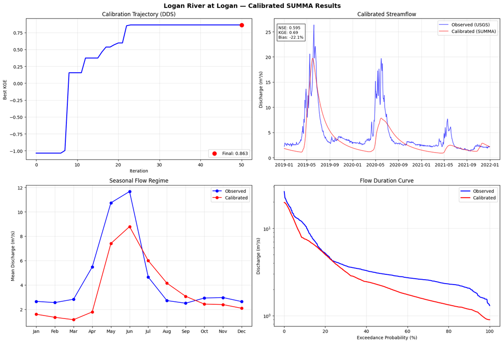

```python
# Load and display calibration results
import json as _json

cal_results = pd.read_csv(results_file)
cal_results['best_score'] = cal_results['score'].cummax()

print("Calibration Progress:")
print(f"  Best {config.optimization.metric}: {cal_results['best_score'].iloc[-1]:.4f}")
print(f"  Initial {config.optimization.metric}: {cal_results['best_score'].iloc[0]:.4f}")
print(f"  Improvement: {cal_results['best_score'].iloc[-1] - cal_results['best_score'].iloc[0]:.4f}")

# --- Load final evaluation metrics and calibrated simulation ---
opt_dir = Path(results_file).parent
fe_dir = opt_dir / 'final_evaluation'

# Final evaluation JSON (calibration + evaluation period metrics)
fe_metrics = {}
fe_jsons = sorted(opt_dir.glob('*_final_evaluation.json'))
if fe_jsons:
    with open(fe_jsons[0]) as _f:
        fe_data = _json.load(_f)
    fe_metrics['calib'] = {k.replace('Calib_', ''): v for k, v in fe_data.get('calibration_metrics', {}).items()}
    fe_metrics['eval'] = {k.replace('Eval_', ''): v for k, v in fe_data.get('evaluation_metrics', {}).items()}
    print(f"\nCalibration period:  KGE={fe_metrics['calib'].get('KGE', 'N/A'):.3f}  "
          f"NSE={fe_metrics['calib'].get('NSE', 'N/A'):.3f}")
    print(f"Evaluation period:   KGE={fe_metrics['eval'].get('KGE', 'N/A'):.3f}  "
          f"NSE={fe_metrics['eval'].get('NSE', 'N/A'):.3f}")

# Use the same post-spinup output window for final comparison
output_start = pd.to_datetime('2019-01-01')
output_end = pd.to_datetime('2022-01-01')

# Load calibrated streamflow from final_evaluation outputs
cal_sim = None
if fe_dir.exists():
    # Prefer CSV files when final evaluation already saved discharge
    for csv_path in sorted(fe_dir.glob('*.csv')):
        _df = pd.read_csv(csv_path, parse_dates=['datetime']).set_index('datetime')
        for col_name in [
            'streamflow_cms',
            'discharge_cms',
            f'{model_name}_discharge_cms',
        ]:
            if col_name in _df.columns:
                cal_sim = _df[col_name]
                break
        if cal_sim is not None:
            break
    if cal_sim is None:
        # Use shared streamflow evaluator for NetCDF model outputs
        from symfluence.evaluation.evaluators.streamflow import StreamflowEvaluator

        streamflow_evaluator = StreamflowEvaluator(config, project_dir=project_dir)
        sim_files = streamflow_evaluator.get_simulation_files(fe_dir)
        if sim_files:
            cal_sim = streamflow_evaluator.extract_simulated_data(sim_files)

if cal_sim is not None:
    cal_sim = cal_sim[
        (cal_sim.index >= output_start) & (cal_sim.index < output_end)
    ]

# Load observed streamflow
obs_dir = project_dir / "data" / "observations" / "streamflow" / "preprocessed"
obs_path = obs_dir / f"{config.domain.name}_streamflow_processed.csv"
cal_obs = None
if obs_path.exists():
    _obs = pd.read_csv(obs_path)
    _obs['datetime'] = pd.to_datetime(_obs['datetime'], utc=True, errors='coerce').dt.tz_convert(None)
    _obs.set_index('datetime', inplace=True)
    cal_obs = _obs['discharge_cms'].resample('D').mean()

# --- Build figure ---
if cal_sim is not None and cal_obs is not None:
    cal_sim_daily = cal_sim.resample('D').mean()
    common = cal_sim_daily.index.intersection(cal_obs.index)
    obs_c = cal_obs.loc[common].dropna()
    sim_c = cal_sim_daily.loc[obs_c.index]
    valid = ~(np.isnan(obs_c.values) | np.isnan(sim_c.values))
    obs_c, sim_c = obs_c[valid], sim_c[valid]

    cal_nse = round(nse(obs_c, sim_c), 3)
    cal_kge = round(kge(obs_c, sim_c), 3)
    cal_pbias = round(pbias(obs_c, sim_c), 1)

    fig, axes = plt.subplots(2, 2, figsize=(16, 11))

    # (0,0) Calibration trajectory
    axes[0, 0].plot(cal_results['iteration'], cal_results['best_score'], 'b-', linewidth=2)
    axes[0, 0].scatter(cal_results['iteration'].iloc[-1], cal_results['best_score'].iloc[-1],
                       color='red', s=80, zorder=5, label=f"Final: {cal_results['best_score'].iloc[-1]:.3f}")
    axes[0, 0].set_xlabel('Iteration')
    axes[0, 0].set_ylabel(f'Best {config.optimization.metric}')
    axes[0, 0].set_title(f'Calibration Trajectory ({config.optimization.algorithm})')
    axes[0, 0].legend(loc='lower right')
    axes[0, 0].grid(True, alpha=0.3)

    # (0,1) Time series — calibrated
    axes[0, 1].plot(obs_c.index, obs_c.values, 'b-', label='Observed (USGS)', linewidth=1.2, alpha=0.7)
    axes[0, 1].plot(sim_c.index, sim_c.values, 'r-', label=f'Calibrated ({model_name})', linewidth=1.2, alpha=0.7)
    axes[0, 1].set_ylabel('Discharge (m³/s)')
    axes[0, 1].set_title('Calibrated Streamflow')
    axes[0, 1].legend()
    axes[0, 1].grid(True, alpha=0.3)
    axes[0, 1].text(0.02, 0.95, f"NSE: {cal_nse}\nKGE: {cal_kge}\nBias: {cal_pbias}%",
                    transform=axes[0, 1].transAxes, verticalalignment='top',
                    bbox=dict(facecolor='white', alpha=0.8), fontsize=9)

    # (1,0) Seasonal flow regime
    mo = obs_c.groupby(obs_c.index.month).mean()
    ms = sim_c.groupby(sim_c.index.month).mean()
    month_names = ['Jan', 'Feb', 'Mar', 'Apr', 'May', 'Jun',
                   'Jul', 'Aug', 'Sep', 'Oct', 'Nov', 'Dec']
    axes[1, 0].plot(mo.index, mo.values, 'b-o', label='Observed', markersize=6)
    axes[1, 0].plot(ms.index, ms.values, 'r-o', label='Calibrated', markersize=6)
    axes[1, 0].set_xticks(range(1, 13))
    axes[1, 0].set_xticklabels(month_names)
    axes[1, 0].set_ylabel('Mean Discharge (m³/s)')
    axes[1, 0].set_title('Seasonal Flow Regime')
    axes[1, 0].legend()
    axes[1, 0].grid(True, alpha=0.3)

    # (1,1) Flow duration curve
    obs_s = obs_c.sort_values(ascending=False)
    sim_s = sim_c.sort_values(ascending=False)
    obs_r = np.arange(1., len(obs_s) + 1) / len(obs_s) * 100
    sim_r = np.arange(1., len(sim_s) + 1) / len(sim_s) * 100
    axes[1, 1].semilogy(obs_r, obs_s, 'b-', label='Observed', linewidth=2)
    axes[1, 1].semilogy(sim_r, sim_s, 'r-', label='Calibrated', linewidth=2)
    axes[1, 1].set_xlabel('Exceedance Probability (%)')
    axes[1, 1].set_ylabel('Discharge (m³/s)')
    axes[1, 1].set_title('Flow Duration Curve')
    axes[1, 1].legend()
    axes[1, 1].grid(True, alpha=0.3)

    plt.suptitle(f'Logan River at Logan — Calibrated {model_name} Results',
                 fontsize=14, fontweight='bold')
    plt.tight_layout()
    plt.show()
else:
    fig, ax = plt.subplots(figsize=(10, 5))
    ax.plot(cal_results['iteration'], cal_results['best_score'], 'b-', linewidth=2)
    ax.set_xlabel('Iteration')
    ax.set_ylabel(f'Best {config.optimization.metric}')
    ax.set_title('Calibration Progress')
    ax.grid(True, alpha=0.3)
    plt.tight_layout()
    plt.show()
    if cal_sim is None:
        print("No calibrated simulation output found in final_evaluation/")
    if cal_obs is None:
        print("No observed streamflow found for comparison")
```

## Step 6 — Benchmarking against reference predictors

If the calibrated model doesn't beat daily climatology, it means the model is reproducing the seasonal cycle but not adding much beyond it. If it does beat the climatology — by how much? Knoben (2024) argues this comparison should be standard practice in every hydrological model evaluation.

```
Evaluation-period KGE (higher is better; max = 1.0):
  Mean flow                      n/a (constant predictor — variance = 0)
  Monthly climatology             0.700
  Daily climatology               0.652
  Calibrated SUMMA                0.340
```

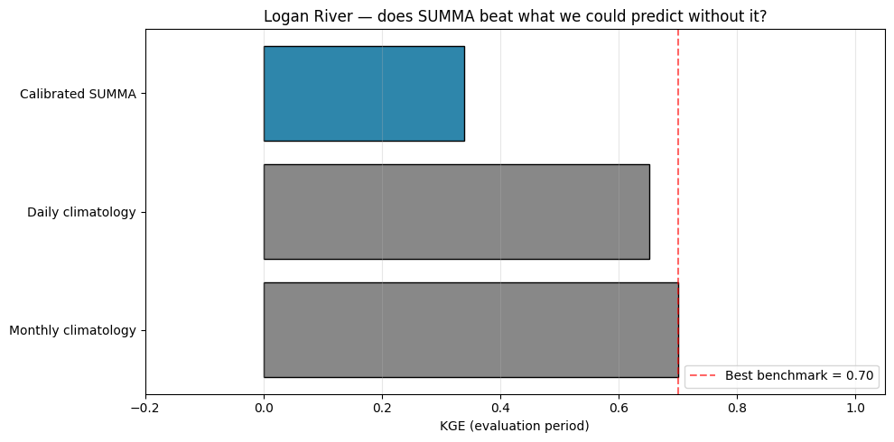

```python
# Step 6 — Benchmarking
opt_dir = Path(results_file).parent
fe_dir = opt_dir / 'final_evaluation'

# Load calibrated simulation
cal_sim_daily = None
if 'cal_sim' in globals() and cal_sim is not None:
    cal_sim_daily = cal_sim.resample('D').mean()
else:
    for csv_path in sorted(fe_dir.glob('*.csv')):
        _df = pd.read_csv(csv_path, parse_dates=['datetime']).set_index('datetime')
        for col in ['streamflow_cms', 'discharge_cms', f'{model_name}_discharge_cms']:
            if col in _df.columns:
                cal_sim_daily = _df[col].resample('D').mean()
                break
        if cal_sim_daily is not None:
            break
    if cal_sim_daily is None and fe_dir.exists():
        from symfluence.evaluation.evaluators.streamflow import StreamflowEvaluator

        streamflow_evaluator = StreamflowEvaluator(config, project_dir=project_dir)
        sim_files = streamflow_evaluator.get_simulation_files(fe_dir)
        if sim_files:
            cal_sim_daily = streamflow_evaluator.extract_simulated_data(sim_files).resample('D').mean()
if cal_sim_daily is None:
    raise FileNotFoundError(f"No calibrated streamflow output found in {fe_dir}")

# Load observations
obs_path = project_dir / "data" / "observations" / "streamflow" / "preprocessed" / f"{config.domain.name}_streamflow_processed.csv"
_obs = pd.read_csv(obs_path)
_obs['datetime'] = pd.to_datetime(_obs['datetime'], utc=True, errors='coerce').dt.tz_convert(None)
_obs.set_index('datetime', inplace=True)
obs_daily = _obs['discharge_cms'].resample('D').mean()

# Periods
cal_start, cal_end = [pd.to_datetime(d.strip()) for d in config.domain.calibration_period.split(',')]
eval_start, eval_end = [pd.to_datetime(d.strip()) for d in config.domain.evaluation_period.split(',')]
obs_cal = obs_daily.loc[cal_start:cal_end].dropna()
obs_eval = obs_daily.loc[eval_start:eval_end].dropna()

sim_eval = cal_sim_daily.loc[obs_eval.index].dropna()
obs_eval_aligned = obs_eval.loc[sim_eval.index]

# Benchmarks (trained on calibration period, applied to evaluation period)
mean_bench = pd.Series(obs_cal.mean(), index=obs_eval_aligned.index)

monthly_clim = obs_cal.groupby(obs_cal.index.month).mean()
monthly_bench = pd.Series([monthly_clim[m] for m in obs_eval_aligned.index.month],
                          index=obs_eval_aligned.index)

doy_clim = obs_cal.groupby(obs_cal.index.dayofyear).mean()
doy_full = pd.Series(index=range(1, 367), dtype=float)
doy_full.update(doy_clim)
doy_full = doy_full.interpolate().ffill().bfill()
daily_bench = pd.Series([doy_full[d] for d in obs_eval_aligned.index.dayofyear],
                        index=obs_eval_aligned.index)

# NaN-safe KGE (constant predictions have zero variance — Pearson r is undefined)
def kge_safe(obs, sim):
    if float(sim.std()) == 0.0 or float(obs.std()) == 0.0:
        return float('nan')
    return kge(obs, sim)

benchmark_kge = {
    'Mean flow': kge_safe(obs_eval_aligned, mean_bench),
    'Monthly climatology': kge_safe(obs_eval_aligned, monthly_bench),
    'Daily climatology': kge_safe(obs_eval_aligned, daily_bench),
    f'Calibrated {model_name}': kge_safe(obs_eval_aligned, sim_eval),
}

print("Evaluation-period KGE (higher is better; max = 1.0):")
for name, score in benchmark_kge.items():
    if np.isnan(score):
        print(f"  {name:<30} n/a (constant predictor — variance = 0)")
    else:
        print(f"  {name:<30} {score:6.3f}")

# Plot only finite-KGE entries
plot_items = [(k, v) for k, v in benchmark_kge.items() if not np.isnan(v)]
names = [k for k, _ in plot_items]
scores = [v for _, v in plot_items]
bar_colors = ['#2E86AB' if model_name in n else '#888888' for n in names]

fig, ax = plt.subplots(figsize=(10, 5))
ax.barh(names, scores, color=bar_colors, edgecolor='black')

benchmark_scores = [v for n, v in plot_items if model_name not in n]
if benchmark_scores:
    best_bench = max(benchmark_scores)
    ax.axvline(x=best_bench, color='red', linestyle='--', alpha=0.6,
               label=f'Best benchmark = {best_bench:.2f}')
    ax.legend(loc='lower right')

ax.set_xlabel('KGE (evaluation period)')
ax.set_title(f'Logan River — does {model_name} beat what we could predict without it?')
ax.grid(True, axis='x', alpha=0.3)
ax.set_xlim(min(min(scores) - 0.1, -0.2), 1.05)
plt.tight_layout()
plt.show()
```